# group2-Kharanshu Patel-CA

Kharanshu Patel

10/6/2018

### Method: CA

Correspondence analysis (ca) is a generalized principal component analysis tailored for the analysis of qualitative data.The goal of correspondence analysis is to transform a data table into two sets of factor scores: One for the rows and one for the columns.

Rows and columns are displayed as points on the map whose coordinates are the factor scores and where the dimensions are called factors.

The factor scores of the rows and the columns have the same variance. Therefore, both rows and columns can be conveniently represented in one single map.

In correspondence analysis, a mass to each row and a weight to each column is assigned. The mass of each row reflects its importance in the sample. The mass of each row is the proportion of this row in the total of the table. The weight of each column reflects its importance for discriminating between the variables. So the weight of a column reflects the information this columns provides to the identification of a given row.

### Dataset : Weekly Earnings by Race

The dataset contains information about the usual weekly earnings of people with various races and gender: White men, White women, Black men, Black women, Asian men, Asian women, Hispanic men, Hispanic women. These are the 8 rows. The 5 columns are 1st decile, 1st quartile, 2nd quartile, 3rd quartile and 9th decile.

```r
setwd('D://acn4/r studio class/')
WE <- read.csv('Weekly Earnings byRace(4).csv', row.names=1)

WE_data <- t(WE)
head(WE_data)
```

```
##             1st decile 1st quartile 2nd quartile 3rd quartile 9th decile
## White.men          412          594          920         1467       2278
## White.women        374          506          743         1140       1726
## Black.men          361          483          680         1046       1551
## Black.Women        331          423          615          935       1453
## Asian.Men          420          648         1129         1860       2699
## Asian.Women        385          551          877         1411       2024
##             Total people (in thousands)
## White.men                         48746
## White.women                       36698
## Black.men                          6445
## Black.Women                        7142
## Asian.Men                          3684
## Asian.Women                        2954
```

```r
head(WE)
```

```
##                             White.men White.women Black.men Black.Women
## 1st decile                        412         374       361         331
## 1st quartile                      594         506       483         423
## 2nd quartile                      920         743       680         615
## 3rd quartile                     1467        1140      1046         935
## 9th decile                       2278        1726      1551        1453
## Total people (in thousands)     48746       36698      6445        7142
##                             Asian.Men Asian.Women Hispanic.Men
## 1st decile                        420         385          358
## 1st quartile                      648         551          451
## 2nd quartile                     1129         877          631
## 3rd quartile                     1860        1411          979
## 9th decile                       2699        2024         1498
## Total people (in thousands)      3684        2954        11142
##                             Hispanic.Women
## 1st decile                             320
## 1st quartile                           404
## 2nd quartile                           566
## 3rd quartile                           830
## 9th decile                            1266
## Total people (in thousands)           7168
```

```r
WE_dummy <- t(WE[(2:4), ])

WE_sup1 <- t(WE[1,])
WE_sup2 <- t(WE[6,]-WE[5,])

WE_col1 <- WE_dummy[,"1st quartile"]
WE_col2 <- WE_dummy[,"2nd quartile"] - WE_dummy[,"1st quartile"]
WE_col3 <- WE_dummy[,"3rd quartile"] - WE_dummy[,"2nd quartile"]
WE_col4 <- WE_data[,"Total people (in thousands)"] - WE_data[,"3rd quartile"]

WE_new <- cbind(WE_col1, WE_col2, WE_col3, WE_col4)
WE_new_t <- t(WE_new)

colnames(WE_new) = c("0-25%","25-50%","50-75%","75-100%")
colnames(WE_sup1) = c("0-10%")
colnames(WE_sup2) = c("90-100%")

WE_heat <- WE_new[ ,(1:3)]
```

## DESIGN

```r
WE_DESIGN_gender <- rep(c("Men", "Women"),4)
WE_DESIGN_race <- rep(c("White", "Black", "Asian", "Hispanic"), each=2)
WE_DESIGN_quart <- rep(c("0-25%","25-50%","50-75%","75-100%"), each = 1)
t(WE_DESIGN_quart)
```

```
##      [,1]    [,2]     [,3]     [,4]
## [1,] "0-25%" "25-50%" "50-75%" "75-100%"
```

```r
## COLOR

col4race2 = c("#00fcfe","#ff2ae3","#000969","#ab0205","#9800ff","#ff6205","#00688b","#ffe61c")

col4quart = c("greenyellow","green","green4","darkolivegreen")
```

### RESULTS

## COMPUTATIONS

# PCA

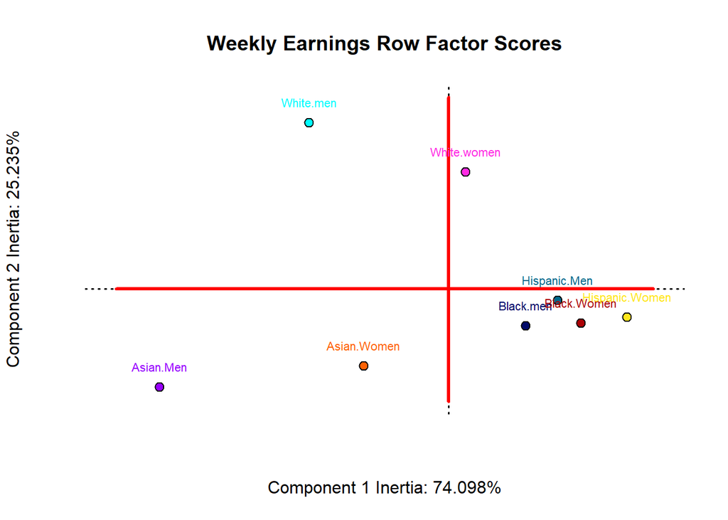

```
## [1] "Contributions dimension mismatch. Defaulting to cex only."
```

```r
resPCA <- epPCA(DATA = WE_new,
                   scale = 'SS1',
                   graphs =  FALSE
                    )
eigs <- resPCA$ExPosition.Data$eigs

PCA.plot.fi <- prettyPlot(resPCA$ExPosition.Data$fi, col = col4race2,
                           display_names = TRUE,
                           dev.new=FALSE,
                           main = "Weekly Earnings Row Factor Scores",
                           x_axis = 1, y_axis = 2,
                           contributionCircles = TRUE,
                           display_points = TRUE, cex = 1.2,
                           fg.col = "red",
                           text.cex = 0.7,
                           pos = 3,
                           axes = TRUE,
                           xlab = paste0("Component 1 Inertia: ",
                           round(resPCA$ExPosition.Data$t[1],3), "%"),
                           ylab = paste0("Component 2 Inertia: ",
                           round(resPCA$ExPosition.Data$t[2],3), "%")
)
```

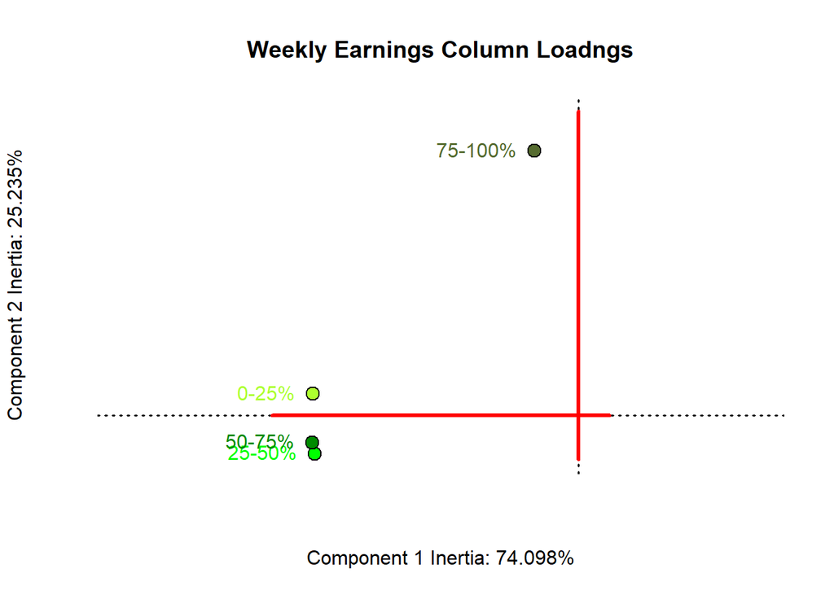

```
## [1] "Contributions dimension mismatch. Defaulting to cex only."
```

```r
PCAplot.fj <- prettyPlot(resPCA$ExPosition.Data$fj, col = col4quart, display_names = TRUE, dev.new=FALSE,
                           main = "Weekly Earnings Column Loadngs",
                           x_axis = 1, y_axis = 2,
                           contributionCircles = TRUE,
                           display_points = TRUE, cex = 1.5,
                           fg.col = "red",
                           text.cex = 1,
                           pos = 2,
                           axes = TRUE,
                           xlab = paste0("Component 1 Inertia: ",
                           round(resPCA$ExPosition.Data$t[1],3), "%"),
                           ylab = paste0("Component 2 Inertia: ",
                           round(resPCA$ExPosition.Data$t[2],3), "%")
)
```

# CA

```r
# symmetric
resCA.sym  <- epCA(WE_new, symmetric = TRUE)
resCA.sym_t <- epCA(WE_new_t, symmetric = TRUE)

# asymmetric
resCA.asym <- epCA(WE_new, symmetric = FALSE)
resCA.asym_t <- epCA(WE_new_t, symmetric = FALSE)


# Supplementary Variables
WE_new_sup1 <- supplementaryCols(SUP.DATA = WE_sup1, res = resCA.sym)
WE_new_sup2 <- supplementaryCols(SUP.DATA = WE_sup2, res = resCA.sym)

# Factor Scores
Fj.a <- resCA.asym$ExPosition.Data$fj
Fi   <- resCA.sym$ExPosition.Data$fi
Fj   <- resCA.sym$ExPosition.Data$fj

Fj.a_t <- resCA.asym_t$ExPosition.Data$fj
Fi_t <- resCA.sym_t$ExPosition.Data$fi
Fj_t   <- resCA.sym_t$ExPosition.Data$fj
```

# Inference battery

```r
resCA.inf <- InPosition::epCA.inference.battery(DATA = WE_new,
                   DESIGN = WE_DESIGN_race,
                   graphs =  FALSE
                   )
```

```
## [1] "It is estimated that your iterations will take 0.25 minutes."
## [1] "R is not in interactive() mode. Resample-based tests will be conducted. Please take note of the progress bar."
## ===========================================================================
```

```r
resCA.inf_t <- InPosition::epCA.inference.battery(DATA = WE_new_t,
                   DESIGN = WE_DESIGN_quart,
                   graphs =  FALSE
                   )
```

```
## [1] "It is estimated that your iterations will take 0.65 minutes."
## [1] "R is not in interactive() mode. Resample-based tests will be conducted. Please take note of the progress bar."
## ===========================================================================
```

## Group Analysis

# Bootstrap for Confidence Intervals:

```r
BootCube.i <- PTCA4CATA::Boot4Mean(Fi,
                                 design = WE_DESIGN_race,
                                 niter = 100,
                                 suppressProgressBar = TRUE)

# Bootstrap ratios
bootRatios.Gr <- boot.ratio.test(BootCube.i$BootCube)

# eigenvalues: MonteCarlo Approach ----
random.eigen <- data4PCCAR::monteCarlo.eigen(X = WE_new, nIter = 100)

# eigenvalues: Bootstrap approach
bootstrap.eigen <- data4PCCAR::boot.eigen(WE_new, nIter = 100)
```

# Constraints

```r
# Constraints
constraints.sym <- minmaxHelper(mat1 = Fi, mat2  = Fj)
constraints.asym <- minmaxHelper(mat1 = Fi, mat2  = Fj.a)
constraints.sup <- minmaxHelper(mat1 = rbind(Fj, WE_new_sup1$fjj),
                                mat2  = rbind(Fj, WE_new_sup2$fjj) )
```

## PLOTTING

# Heat Map(Not Correlation)

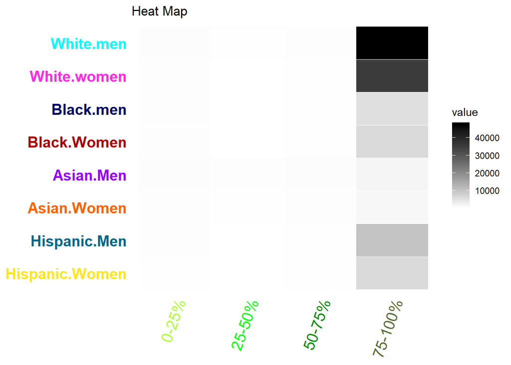

```r
heatMapIJ.WE <- makeggHeatMap4CT(WE_new,
colorAttributes = col4quart,
colorProducts = col4race2,
fontSize.x = 15
) + ggtitle('Heat Map')

print(heatMapIJ.WE)
```

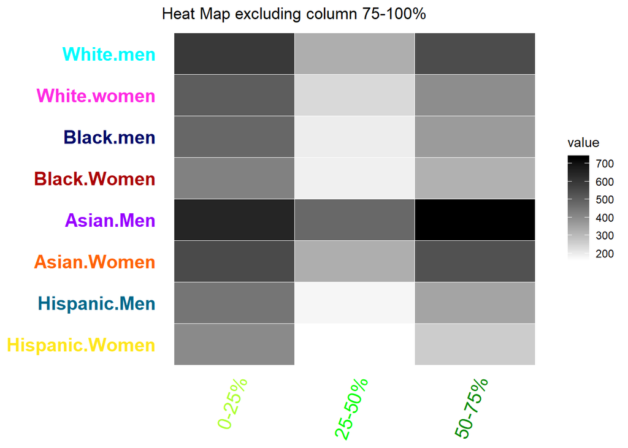

```r
# Heat Map after removing 4th column: 75-100%
heatMapIJ.WE2 <- makeggHeatMap4CT(WE_heat,
colorAttributes = col4quart,
colorProducts = col4race2,
fontSize.x = 15) + ggtitle('Heat Map excluding column 75-100%')

print(heatMapIJ.WE2)
```

## Scree Plot + Inference (Permutation Results)

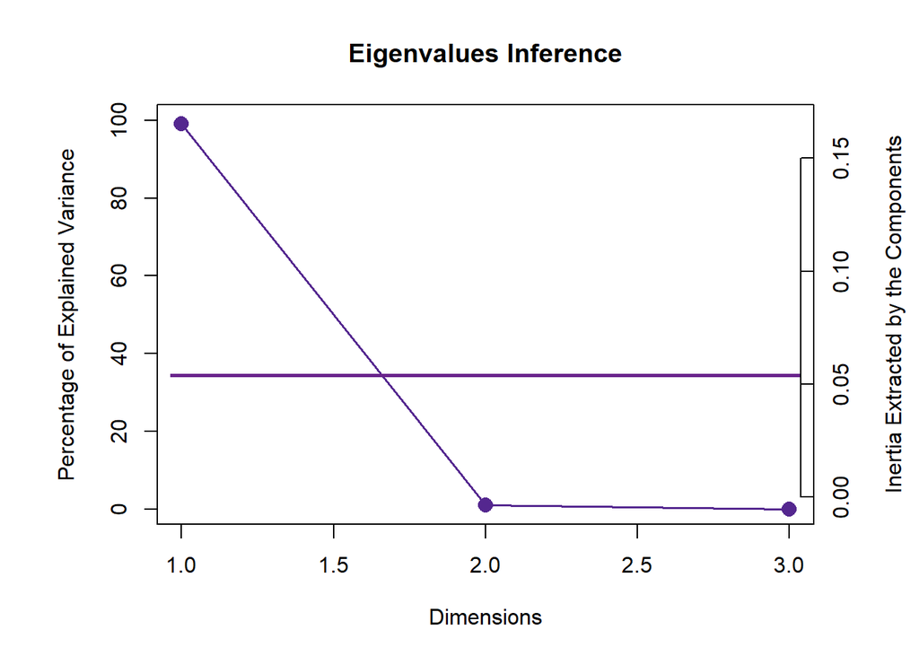

```r
# Scree Plot with Permutation Test

PlotScree(ev = resCA.sym$ExPosition.Data$eigs,
       p.ev = resCA.inf$Inference.Data$components$p.vals,
       title = 'Eigenvalues Inference',
       plotKaiser = TRUE
          )
```

# Base Map

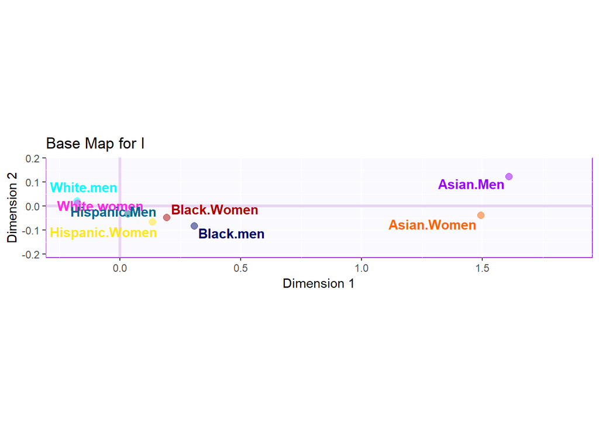

```r
baseMap.i <- createFactorMap(Fi, constraints = constraints.sym,
                             col.points = col4race2,
                             col.labels = col4race2,
                             title = "Base Map for I")
print(baseMap.i$zeMap)
```

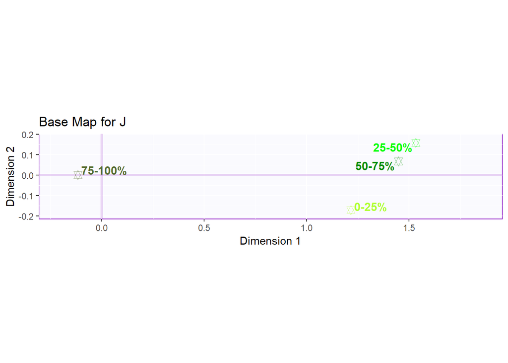

```r
baseMap.j <- createFactorMap(Fj, constraints = constraints.sym,
                             col.points = col4quart,
                             col.labels = col4quart,
                             pch = 11,
                             title = "Base Map for J")
print(baseMap.j$zeMap)
```

# Varimax Rotations

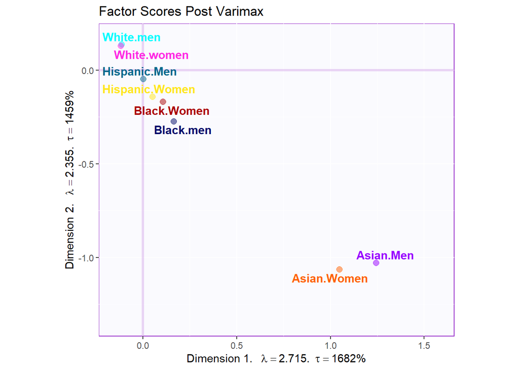

```r
testVari    <- data4PCCAR::epVari(resCA.sym)

# Plot Varimax Rotations
# Labels

labels4Vari <- PTCA4CATA::createxyLabels.gen(1,2,
                                    lambda = testVari$rotated.eigs,
                                     tau = testVari$rotated.t)

# Plot the Rotated observations
# a graph for the observations

baseMap.i.rot <- PTCA4CATA::createFactorMap(testVari$rotated.I,
  col.points = col4race2,
  col.labels = col4race2,
  display.labels = TRUE,
  alpha.points = .5,
  title = 'Factor Scores Post Varimax'
)
Map.I.rot <- baseMap.i.rot$zeMap + labels4Vari
print(Map.I.rot)
```

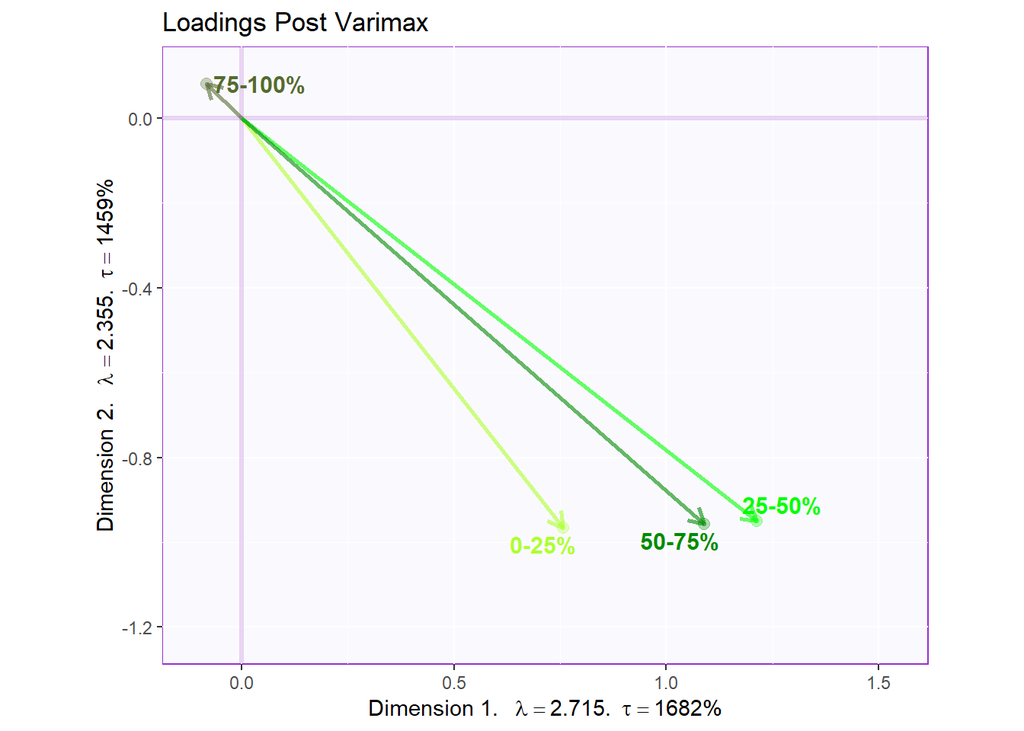

```r
baseMap.j.rot <- PTCA4CATA::createFactorMap(testVari$rotated.J,
                                  col.points   = col4quart,
                                   alpha.points =  .3,
                                   col.labels   = col4quart,
                                   title = 'Loadings Post Varimax')
# arrows
zeArrows.rot <- addArrows(testVari$rotated.J, color = col4quart)
# A graph for the J-set
Map.J.rot <- baseMap.j.rot$zeMap_background +
                     baseMap.j.rot$zeMap_dots +
                     baseMap.j.rot$zeMap_text +
                     zeArrows.rot + labels4Vari
print(Map.J.rot)
```

## Factor Scores : Symmetric

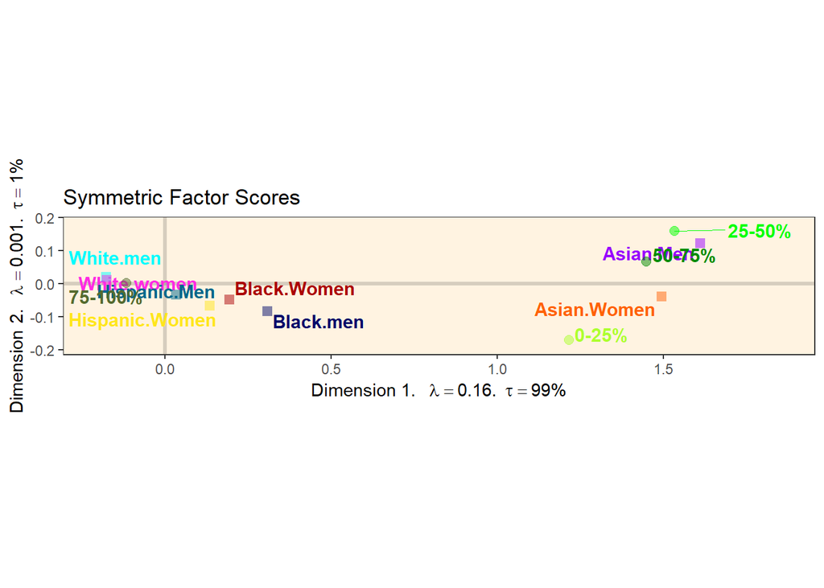

```r
# Symmetric map for I and J
symMap  <- createFactorMapIJ(Fi,Fj,
                             col.points.i = col4race2,
                             col.labels.i = col4race2,
                             col.points.j = col4quart,
                             col.labels.j = col4quart,
                             constraints = constraints.sym,
                             pch.i = 15, pch.j = 19,
                             alpha.labels.i = 0.8,
                             alpha.labels.j = 0.8,
                             alpha.axes = 0.2,
                             col.axes = "#333434",
                             col.background = "#fff3e1",
                             title = "Symmetric Factor Scores"
                             )

# Labels
labels4CA <- PTCA4CATA::createxyLabels.gen(1,2, lambda = resCA.sym$ExPosition.Data$eigs, tau = resCA.sym$ExPosition.Data$t)

map.IJ.sym <- symMap$baseMap + symMap$I_labels + symMap$I_points +
  symMap$J_labels + symMap$J_points + labels4CA +
  theme(panel.grid.major = element_blank(), panel.grid.minor = element_blank())

print(map.IJ.sym)
```

## Factor Scores : Asymmetric

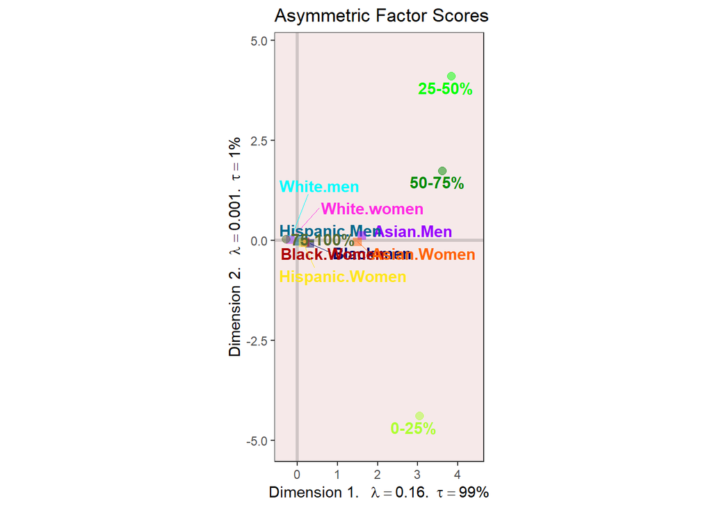

```r
asymMap  <- createFactorMapIJ(Fi,Fj.a,
                              col.points.i = col4race2,
                              col.labels.i = col4race2,
                              col.points.j = col4quart,
                              col.labels.j = col4quart,
                              constraints = constraints.asym,
                              pch.i = 15, pch.j = 19,
                              alpha.labels.i = 0.8,
                              alpha.labels.j = 0.8,
                              alpha.axes = 0.2,
                              col.axes = "#333434",
                              col.background = "#f6e9e9",
                              title = "Asymmetric Factor Scores"
                              )

map.IJ.asym <- asymMap$baseMap + asymMap$I_labels +
  asymMap$I_points + asymMap$J_labels +
  asymMap$J_points + labels4CA +
  theme(panel.grid.major = element_blank(), panel.grid.minor = element_blank())

print(map.IJ.asym)
```

## Plot Supplemenatary variables

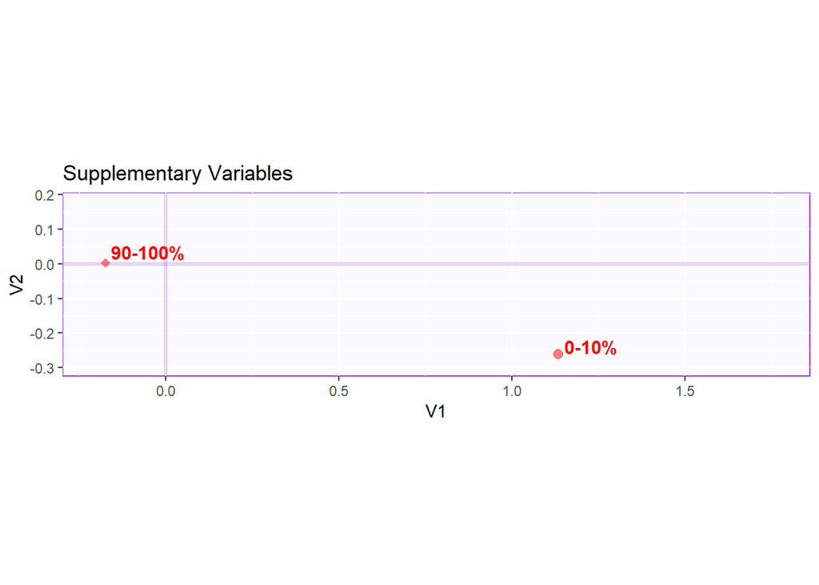

```r
# Supplementary variables: 1st decile, 9th decile
# Base Map
mapSup <- createFactorMapIJ(as.data.frame(WE_new_sup1$fjj),
                            as.data.frame(WE_new_sup2$fjj),
                            col.points.i = "red1",
                            col.labels.i = 'red1',
                            col.points.j = 'red1',
                            col.labels.j = 'red1',
                            constraints = constraints.sup
)
map.sup <- mapSup$baseMap + mapSup$I_labels + mapSup$I_points + mapSup$J_labels + mapSup$J_points + ggtitle('Supplementary Variables')
print(map.sup)
```

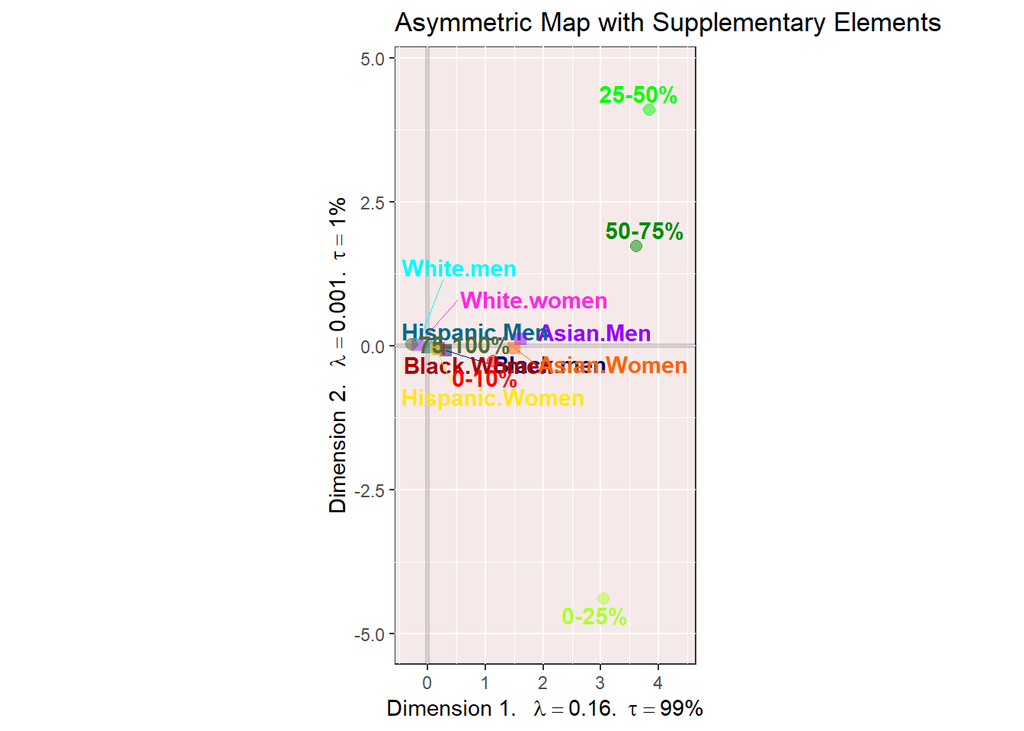

```r
# create an asymmetric map with a supplementary row
map.IJ.sup.asym <- asymMap$baseMap + asymMap$I_labels +
  asymMap$I_points +
  asymMap$J_labels + asymMap$J_points +
  mapSup$I_labels + mapSup$I_points +
  ggtitle('Asymmetric Map with Supplementary Elements') +
  labels4CA

print(map.IJ.sup.asym)
```

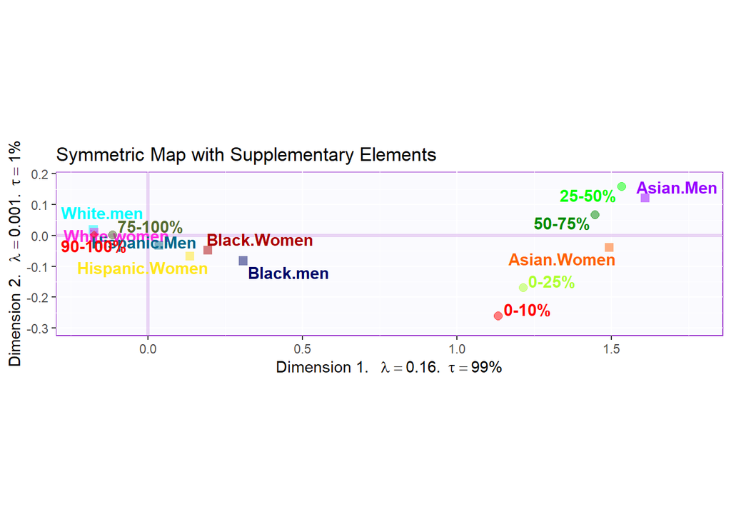

```r
# Create a symmetric map with sup and correct constraints
map.IJ.sup.sym <- mapSup$baseMap +
  symMap$I_labels + symMap$I_points +
  symMap$J_labels + symMap$J_points +
  mapSup$I_labels + mapSup$I_points +
  mapSup$J_labels + mapSup$J_points +
  ggtitle('Symmetric Map with Supplementary Elements') +
  labels4CA

print(map.IJ.sup.sym)
```

## Contribution Bars

```r
# I set
## Signed Contributions
signed.ctrI <- resCA.sym$ExPosition.Data$ci * sign(resCA.sym$ExPosition.Data$fi)

## Unsigned Contributions
unsigned.ctrI <- resCA.asym$ExPosition.Data$ci

# J set
## Signed Contributions
signed.ctrJ <- resCA.sym$ExPosition.Data$cj * sign(resCA.sym$ExPosition.Data$fj)

## Unsigned Contributions
unsigned.ctrJ <- resCA.asym$ExPosition.Data$cj
```

# I set : Signed Contributions # 1

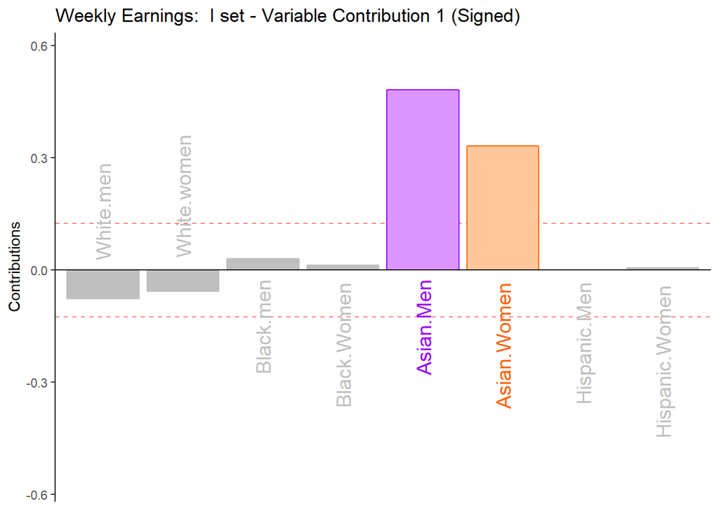

```r
ctrI.s.1 <- PrettyBarPlot2(signed.ctrI[,1],
                         threshold = 1 / NROW(signed.ctrI),
                         font.size = 5,
                         color4bar = gplots::col2hex(col4race2),
                         main = 'Weekly Earnings:  I set - Variable Contribution 1 (Signed)',
                         ylab = 'Contributions',
                         ylim = c(1.2*min(signed.ctrI), 1.2*max(signed.ctrI))
)

print(ctrI.s.1)
```

# I set : Signed Contributions # 2

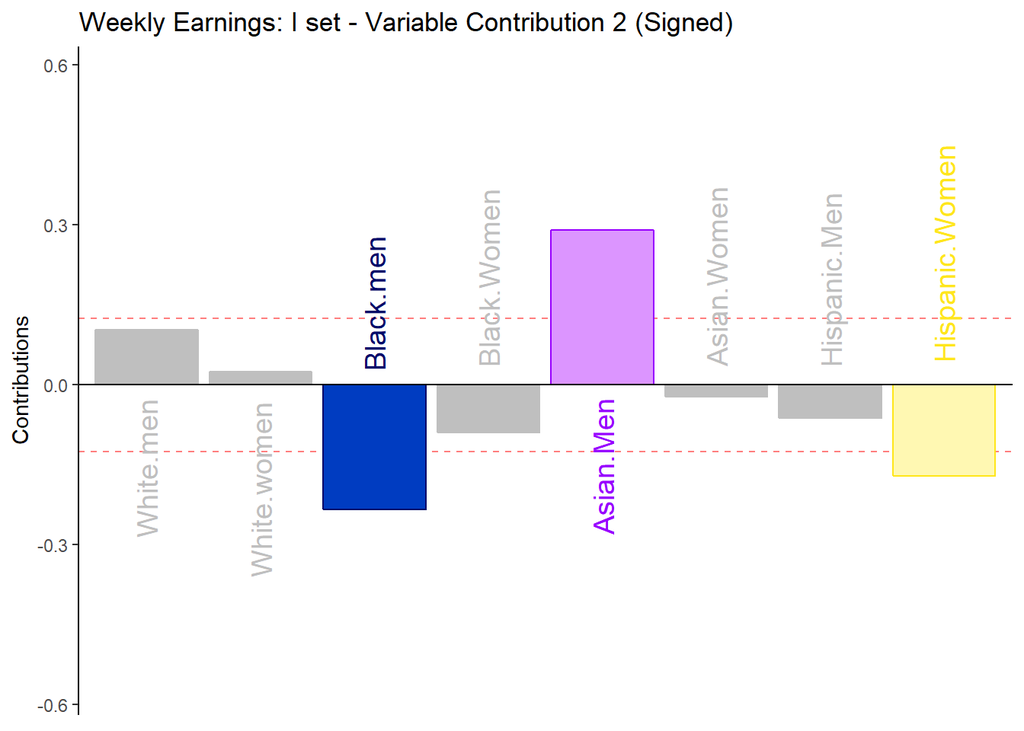

```r
ctrI.s.2 <- PrettyBarPlot2(signed.ctrI[,2],
                           threshold = 1 / NROW(signed.ctrI),
                           font.size = 5,
                           color4bar = gplots::col2hex(col4race2),
                           main = 'Weekly Earnings: I set - Variable Contribution 2 (Signed)',
                           ylab = 'Contributions',
                           ylim = c(1.2*min(signed.ctrI), 1.2*max(signed.ctrI))
)

print(ctrI.s.2)
```

# J set : Signed Contributions # 1

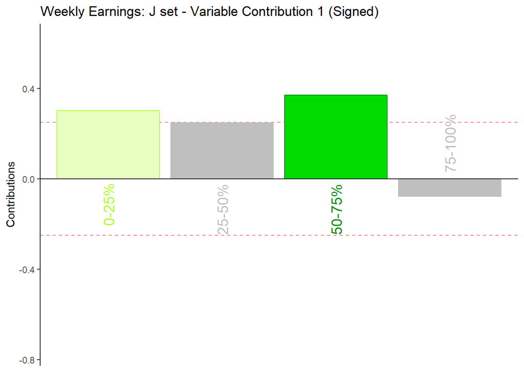

```r
ctrJ.s.1 <- PrettyBarPlot2(signed.ctrJ[,1],
                         threshold = 1 / NROW(signed.ctrJ),
                         font.size = 5,
                         color4bar = gplots::col2hex(col4quart),
                         main = 'Weekly Earnings: J set - Variable Contribution 1 (Signed)',
                         ylab = 'Contributions',
                         ylim = c(1.2*min(signed.ctrJ), 1.2*max(signed.ctrJ))
)

print(ctrJ.s.1)
```

# J set : Signed Contributions # 2

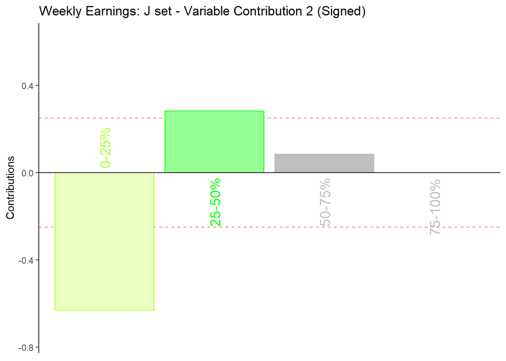

```r
ctrJ.s.2 <- PrettyBarPlot2(signed.ctrJ[,2],
                           threshold = 1 / NROW(signed.ctrJ),
                           font.size = 5,
                           color4bar = gplots::col2hex(col4quart),
                           main = 'Weekly Earnings: J set - Variable Contribution 2 (Signed)',
                           ylab = 'Contributions',
                           ylim = c(1.2*min(signed.ctrJ), 1.2*max(signed.ctrJ))
)

print(ctrJ.s.2)
```

# I set : Unsigned Contributions # 1

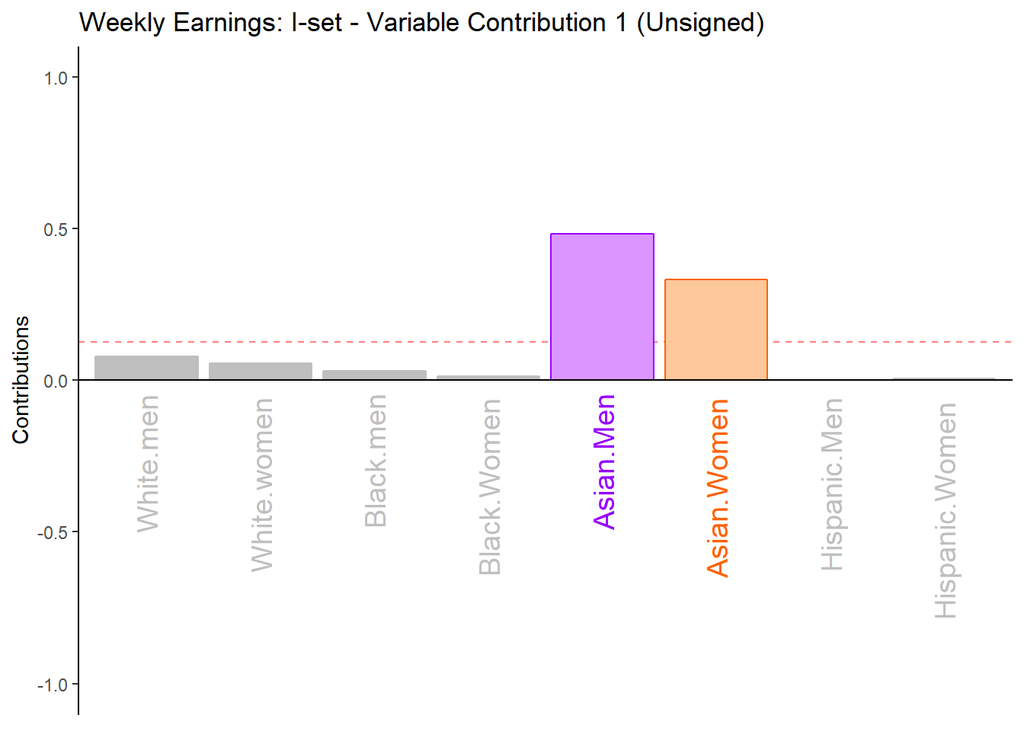

```r
ctrI.u.1 <- PrettyBarPlot2(unsigned.ctrI[,1],
                         threshold = 1 / NROW(unsigned.ctrI),
                         font.size = 5,
                         horizontal = TRUE,
                         color4bar = gplots::col2hex(col4race2),
                         main = 'Weekly Earnings: I-set - Variable Contribution 1 (Unsigned)',
                         ylab = 'Contributions',
                         ylim = c(-1,1)
)
print(ctrI.u.1)
```

# I set : Unsigned Contributions # 2

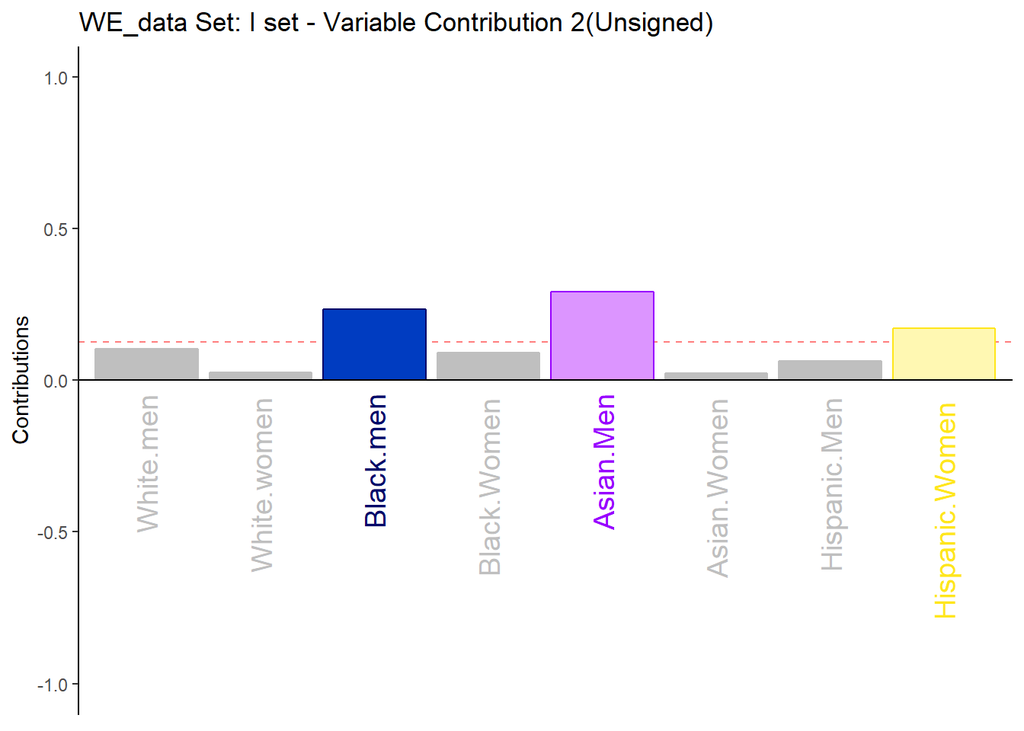

```r
ctrI.u.2 <- PrettyBarPlot2(unsigned.ctrI[,2],
                           threshold = 1 / NROW(unsigned.ctrI),
                           font.size = 5,
                           color4bar = gplots::col2hex(col4race2),
                           main = 'WE_data Set: I set - Variable Contribution 2(Unsigned)',
                           ylab = 'Contributions',
                           ylim = c(-1,1)
)
print(ctrI.u.2)
```

# J set : Unsigned Contributions # 1

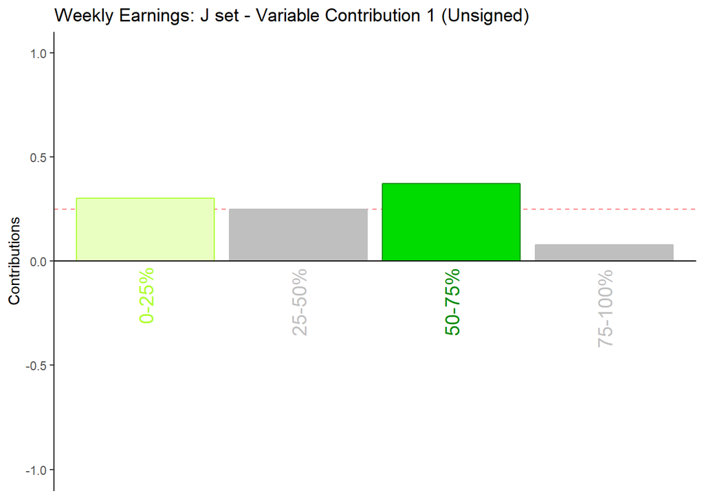

```r
ctrJ.u.1 <- PrettyBarPlot2(unsigned.ctrJ[,1],
                         threshold = 1 / NROW(unsigned.ctrJ),
                         font.size = 5,
                         color4bar = gplots::col2hex(col4quart),
                         main = 'Weekly Earnings: J set - Variable Contribution 1 (Unsigned)',
                         ylab = 'Contributions',
                         ylim = c(-1,1)
)
print(ctrJ.u.1)
```

# J set : Unsigned Contributions # 2

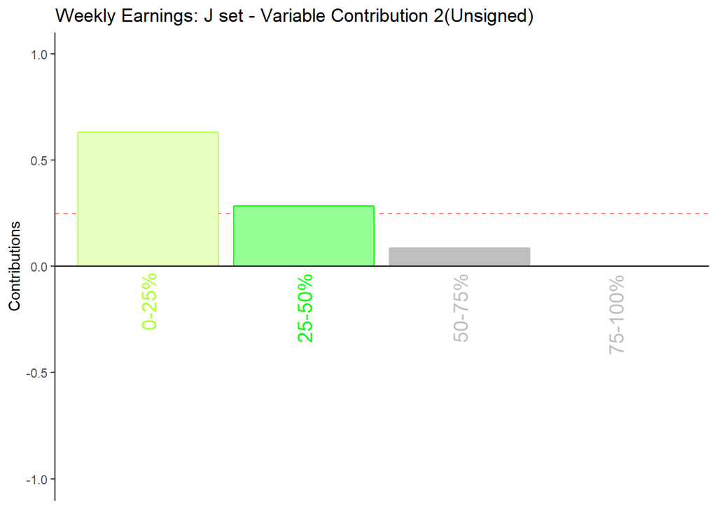

```r
ctrJ.u.2 <- PrettyBarPlot2(unsigned.ctrJ[,2],
                           threshold = 1 / NROW(unsigned.ctrJ),
                           font.size = 5,
                           color4bar = gplots::col2hex(col4quart),
                           main = 'Weekly Earnings: J set - Variable Contribution 2(Unsigned)',
                           ylab = 'Contributions',
                           ylim = c(-1,1)
)
print(ctrJ.u.2)
```

## Bootstrap Ratio Bars

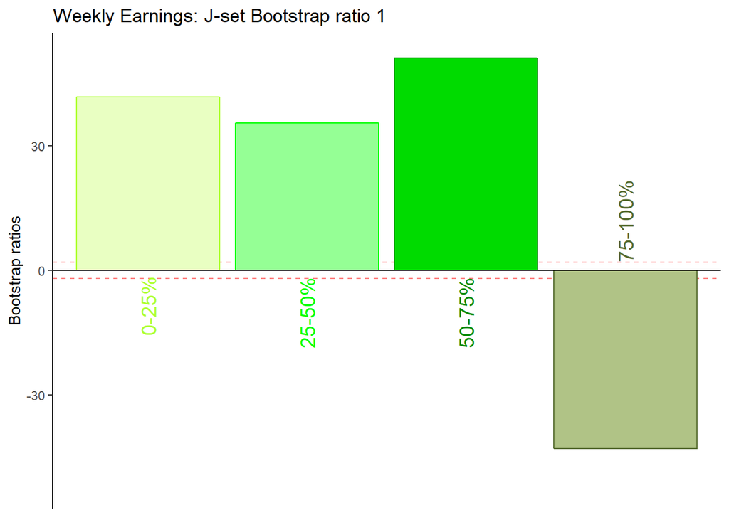

```r
BR.i <- resCA.inf$Inference.Data$fj.boots$tests$boot.ratios
BR.j <- resCA.inf_t$Inference.Data$fj.boots$tests$boot.ratios

## J-set Dimension 1
laDim = 1
map.BR1.j <- PrettyBarPlot2(BR.i[,laDim],
                        threshold = 2,
                        font.size = 5,
                   color4bar = gplots::col2hex(col4quart),
                   main = paste0(
                     'Weekly Earnings: J-set Bootstrap ratio ',laDim),
                  ylab = 'Bootstrap ratios'
                  #ylim = c(1.2*min(BR[,laDim]), 1.2*max(BR[,laDim]))
)
print(map.BR1.j)
```

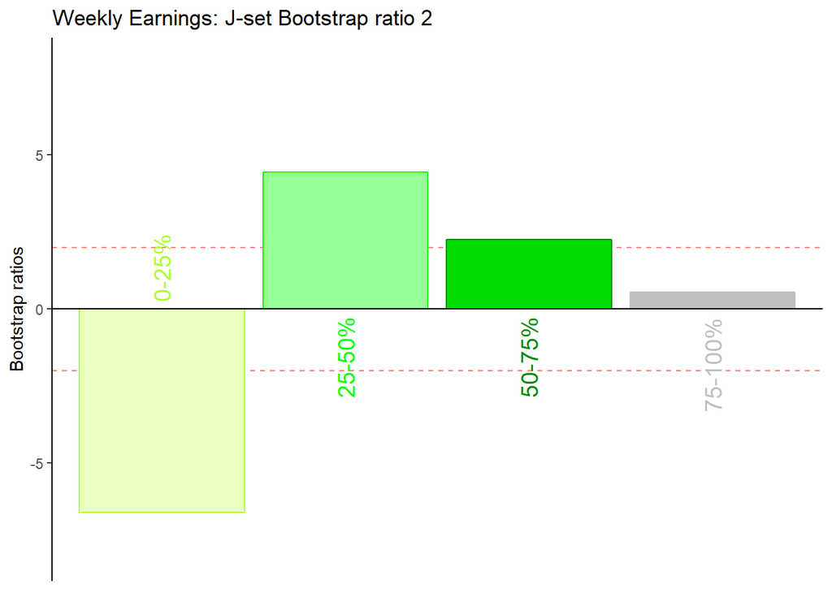

```r
## J-set Dimension 2
laDim = 2
map.BR2.j <- PrettyBarPlot2(BR.i[,laDim],
                            threshold = 2,
                            font.size = 5,
                            color4bar = gplots::col2hex(col4quart),
                            main = paste0(
                              'Weekly Earnings: J-set Bootstrap ratio ',laDim),
                ylab = 'Bootstrap ratios'
)
print(map.BR2.j)
```

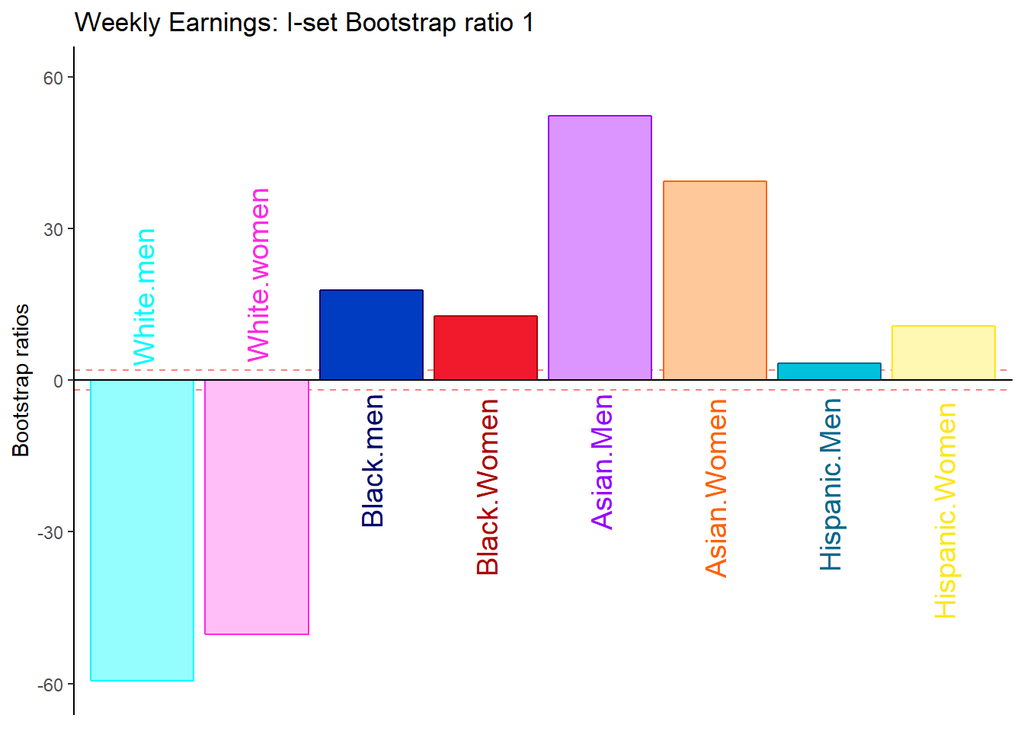

```r
## I-set Dimension 1
laDim = 1
map.BR1.i <- PrettyBarPlot2(BR.j[,laDim],
                        threshold = 2,
                        font.size = 5,
                   color4bar = gplots::col2hex(col4race2),
                   main = paste0(
                     'Weekly Earnings: I-set Bootstrap ratio ',laDim),
                  ylab = 'Bootstrap ratios'
                  #ylim = c(1.2*min(BR[,laDim]), 1.2*max(BR[,laDim]))
)
print(map.BR1.i)
```

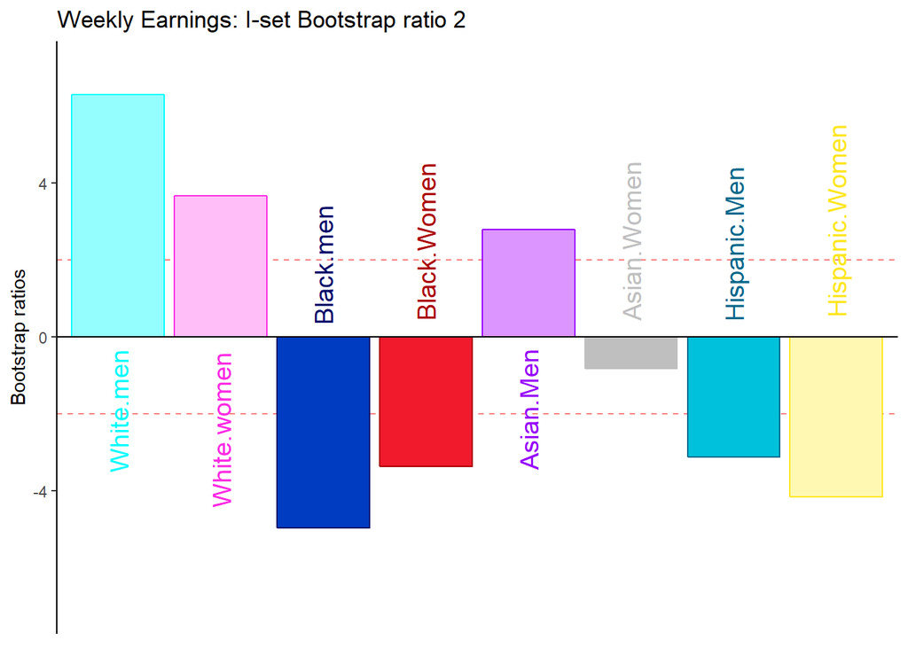

```r
## I-set Dimension 2
laDim = 2
map.BR2.i <- PrettyBarPlot2(BR.j[,laDim],
                            threshold = 2,
                            font.size = 5,
                            color4bar = gplots::col2hex(col4race2),
                            main = paste0(
                              'Weekly Earnings: I-set Bootstrap ratio ',laDim),
                ylab = 'Bootstrap ratios'
)
print(map.BR2.i)
```